# Chapter 04, Problem Set Key

### 4.1

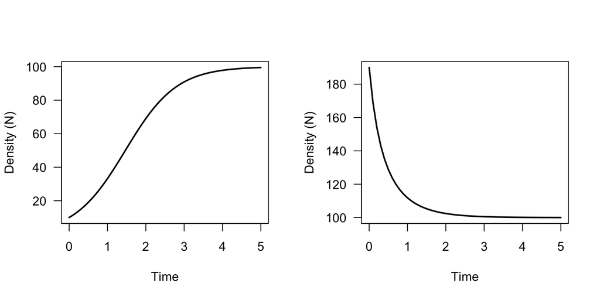

```r
times_4.1 <- seq(from = 0, to = 5, by = 0.1)
r <- 1.5
K <- 100
N0_4.1_10 <- 10
Nt_4.1_10 <- (K*N0_4.1_10)/((K - N0_4.1_10)*exp(-r*times_4.1) + N0_4.1_10)

N0_4.1_190 <- 190
Nt_4.1_190 <- (K*N0_4.1_190)/((K - N0_4.1_190)*exp(-r*times_4.1) + N0_4.1_190)

par(mfrow = c(1, 2))
plot(x = times_4.1, y = Nt_4.1_10, las = 1, ylab = "Density (N)", xlab = "Time", type = "l", lwd = 2)
plot(x = times_4.1, y = Nt_4.1_190, las = 1, ylab = "Density (N)", xlab = "Time", type = "l", lwd = 2)
```

### 4.2

Repeat exercise 4.1 wth $r= -0.1$. (Use a time frame of 0 to 100 with intervals of at least 1.0.)

(Whoops, I forgot to include that I wanted two different $N(0)$s, including for 4.1)

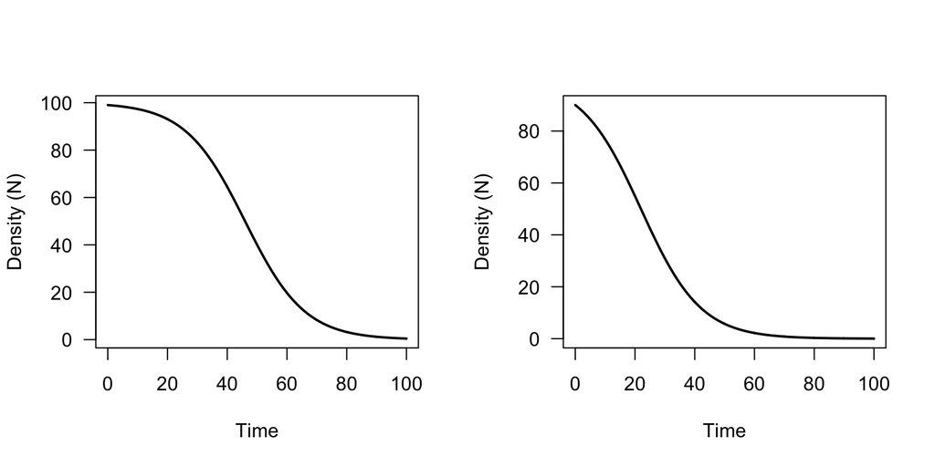

```r
times_4.2 <- seq(from = 0, to = 100, by = 0.1)
r <- -0.1
K <- 100
N0_4.2_10 <- 99
Nt_4.2_10 <- (K*N0_4.2_10)/((K - N0_4.2_10)*exp(-r*times_4.2) + N0_4.2_10)

N0_4.2_190 <- 90
Nt_4.2_190 <- (K*N0_4.2_190)/((K - N0_4.2_190)*exp(-r*times_4.2) + N0_4.2_190)

par(mfrow = c(1, 2))
plot(x = times_4.2, y = Nt_4.2_10, las = 1, ylab = "Density (N)", xlab = "Time", type = "l", lwd = 2)
plot(x = times_4.2, y = Nt_4.2_190, las = 1, ylab = "Density (N)", xlab = "Time", type = "l", lwd = 2)
```

When death rates are greater than birth rates and if the population is *below* its positive equilibrium (“carrying capacity”), then the population shrinks to 0. When death rates are greater than birth rates and if the population is *above* its positive equilibrium, then the population grows (strange—right?) then becomes negative (this is getting weirder), and lastly grows again until it asymptotes at 0.

### 4.3

Recall the population model of the Ricker equation from chapter 1,
$$N_{t+1} = rN_t\exp(1 - bN_t)$$
. Let $r = 2.5$ and $b = 2.5$ and project the population 45 times units, beginning with a starting population size of 0.01. What is the pattern of the time series Let $r = 4$ and $b=0.7$ and project the time series 45 times, beginning with a starting population of 3.5. Now what is the pattern of the time series?

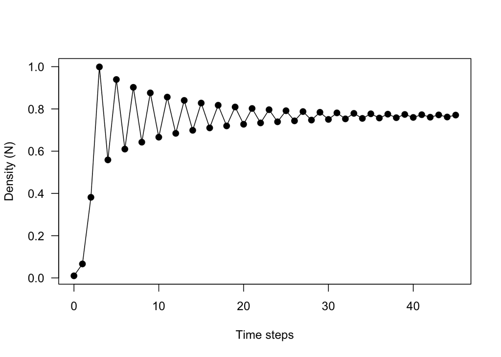

```r
Ricker <- function(t, N, parms) {
  with(as.list(c(N, parms)), {
  Nt <- r*N*exp(1 - b*N)
  return(list(Nt))
  })
}

N0_4.3_a <- 0.01
parameters_a <- c(r = 2.5, b = 2.5)
times_4.3_a <- 0:45
out_4.3_a <- ode(y = N0_4.3_a, times = times_4.3_a, func = Ricker, parms = parameters_a, method = "iteration")
plot(x = out_4.3_a[,1], y = out_4.3_a[,2], las = 1, pch = 16, cex = 1.25, xlab = "Time steps", ylab = "Density (N)")
lines(x = out_4.3_a[,1], y = out_4.3_a[,2])
```

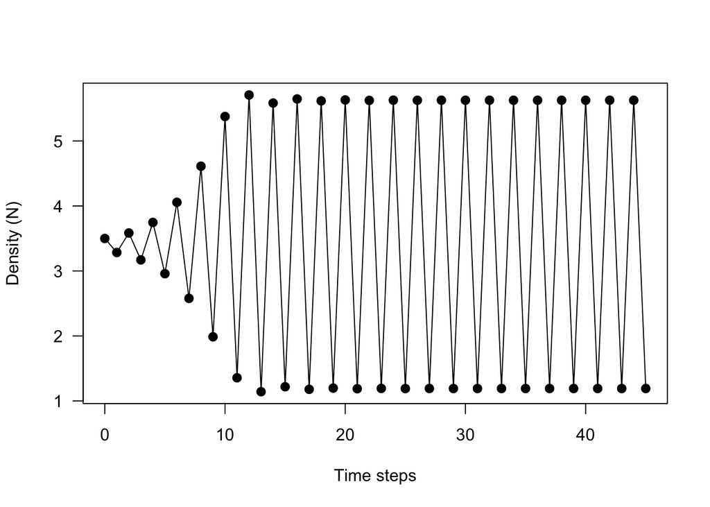

```r
N0_4.3_b <- 3.5
parameters_b <- c(r = 4, b = 0.7)
times_4.3_b <- 0:45
out_4.3_b <- ode(y = N0_4.3_b, times = times_4.3_b, func = Ricker, parms = parameters_b, method = "iteration")
plot(x = out_4.3_b[,1], y = out_4.3_b[,2], las = 1, pch = 16, cex = 1.25, xlab = "Time steps", ylab = "Density (N)")
lines(x = out_4.3_b[,1], y = out_4.3_b[,2])
```

The pattern of the time series for the first part is that the popluation fluxuates towards around a density just under 0.8, with the fluctuations dampening over time. In the second part, the population fluctuations increase over time, but eventually max and min out at just over 5 and 1, respectively.

### 4.4

A simple model of predator ($P$) and prey ($V$, for victim) omteractomg om doscrete time is, for the prey,
$$V_{t+1} = bV_t\left(\frac{K - V_t}{K}\right)\exp \left(-aP_t\right)$$
and for the predator,
$$P_{t+1} = cV_t\left(1 - \exp \left(-aP_t\right)\right).$$
This model will be developed more fully in chapter 6. For now just examine the time series it generates. Use the parameters $a = 0.1$, $b = 1.5$, $K = 40$, and $c = 1.5$. Make a graph of the two species over time (from 0 to 200), and plot the two species on a graph of predator versus prey, showing the direction of change with arrows

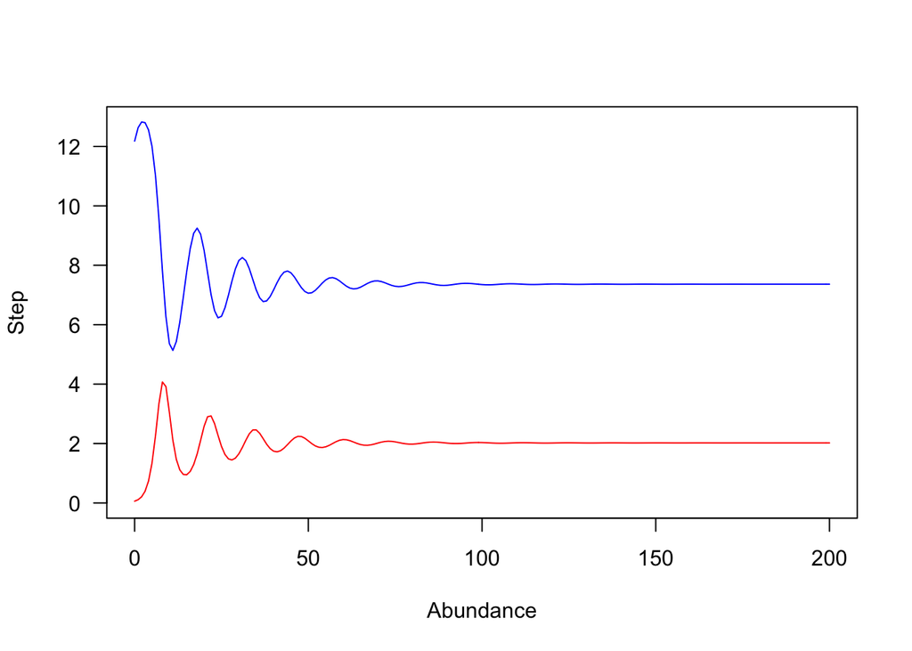

```r
PV.disc <- function(t, state, parms) {
  b <- 1.5
  K <- 40
  a <- 0.1
  c <- 1.5
  V <- state["V"]
  P <- state["P"]
  Vt1 <- b*V*((K - V) / K)*exp(-a*P)
  Pt1 <- c*V*(1 - exp(-a*P))
  return(list(c(Vt1, Pt1)))
}

steps.vec <- seq(from = 0, to = 200, by = 1)
init.Ns <- c(V = 12.18, P = 0.06)

odeOut.2.14 <- ode(y = init.Ns, times = steps.vec, func = PV.disc, parms = NA, method = "iteration")

plot(x = steps.vec, y = odeOut.2.14[,2], type = "l", col = "blue", ylab = "Step", xlab = "Abundance", ylim = c(0, max(odeOut.2.14[,2:3])), las = 1)
lines(x = steps.vec, y = odeOut.2.14[,3], col = "red")
```

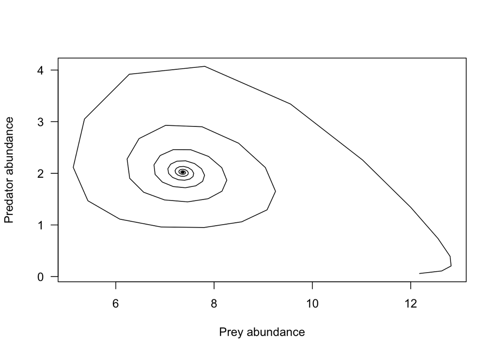

```r
plot(x = odeOut.2.14[,2], y = odeOut.2.14[,3], type = "l", xlab = "Prey abundance", ylab = "Predator abundance", las = 1)
```

### 4.5

A even simpler model (again, to be developed in chapter 6) is
$$\begin{align}
V_{t+1} &= bV_t - mV_tP_t \\
P_{t+1} &= b'V_tP_t - m'P_t.
\end{align}$$
Repeat exercise 4.4 with this model and the parameters $b = 1.1$, $m = 0.8$, $b' = 0.5$, and $m'=0.002$.

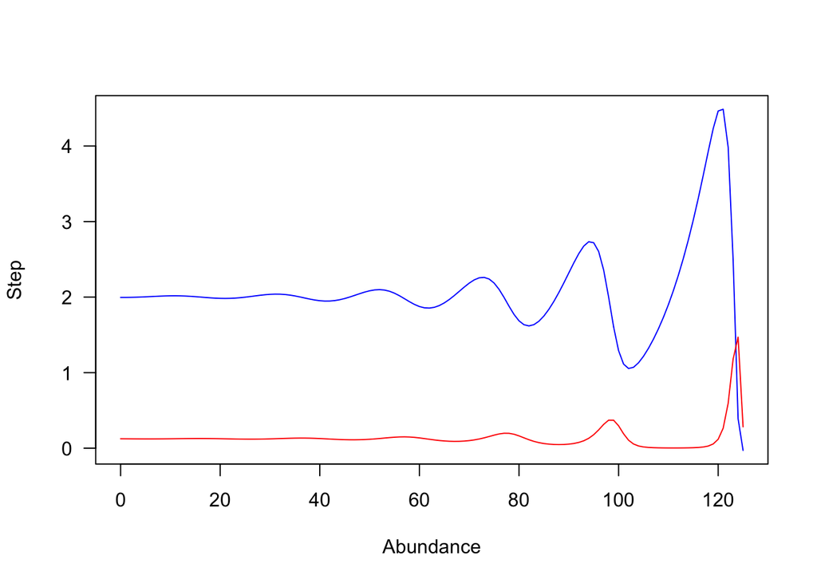

```r
PV.disc.4.5 <- function(t, state, parms) {
  b <- 1.1
  m = 0.8
  b1 = 0.5
  m1 = 0.002
  V <- state["V"]
  P <- state["P"]
  Vt1 <- b*V - m*V*P
  Pt1 <- b1*V*P - m1*P
  return(list(c(Vt1, Pt1)))
}

steps.vec <- seq(from = 0, to = 200, by = 1)
init.Ns <- c(V = 1.996, P = 0.125)

odeOut.2.15 <- ode(y = init.Ns, times = steps.vec, func = PV.disc.4.5, parms = NA, method = "iteration")

pos.steps <- 1:min(which(odeOut.2.15[,2:3] < 0, arr.ind = T)[,1])

plot(x = steps.vec[pos.steps], y = odeOut.2.15[pos.steps, 2], type = "l", col = "blue", ylab = "Step", xlab = "Abundance", ylim = , las = 1)
lines(x = steps.vec[pos.steps], y = odeOut.2.15[pos.steps, 3], col = "red")
```

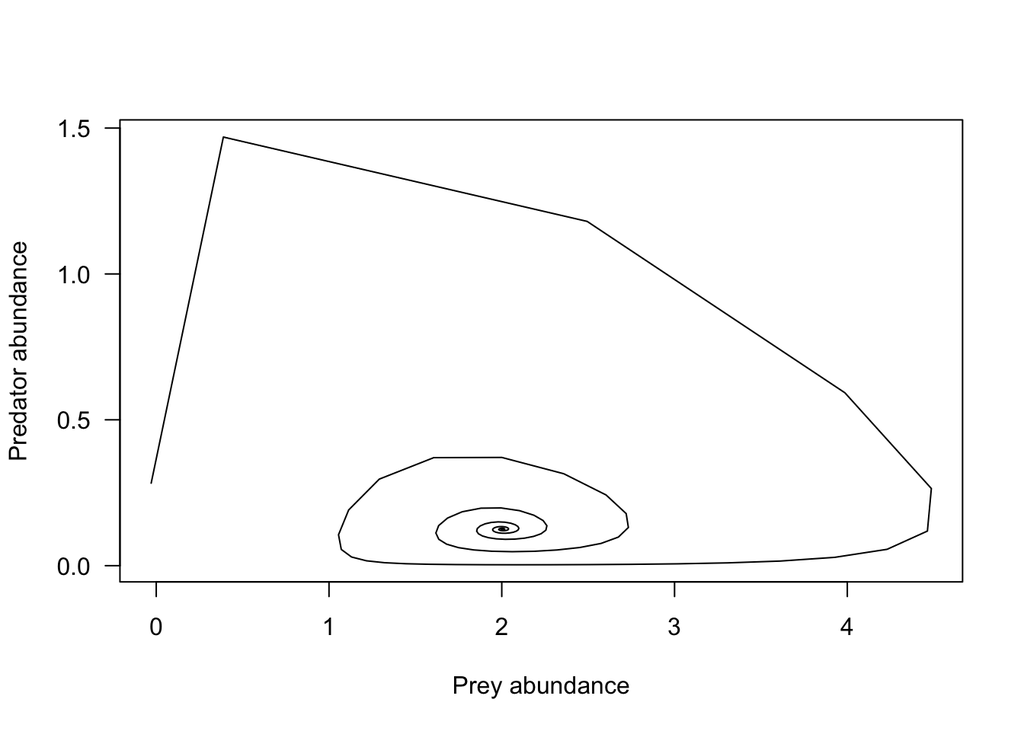

```r
plot(x = odeOut.2.15[pos.steps, 2], y = odeOut.2.15[pos.steps, 3], type = "l", xlab = "Prey abundance", ylab = "Predator abundance", las = 1)
```

### 4.6

The basic exponential decribes the dynamics of a single population, which means that it is a dynamic system in one dimension. Its only equilibrium values is $N^* = 0$. Draw the state space (a line), showing with small arrows the dynamical nature of the system near the equilibrium point. Make a graph of the derivative ($dN/dt$) as a function of $N$ for $r = 1.0$ and $1.5$.

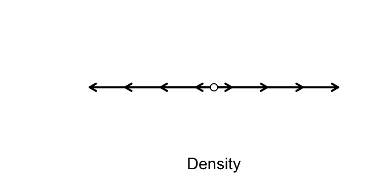

```r
arrow.heads <- seq(from = -1, to = 1, length.out = 8)
n.arrows <- length(arrow.heads)

plot(x = c(-1, 1), y = c(0, 0), type = "n", axes = F, xlab = "Density", ylab  = "")
arrows(x0 = rep(x = 0, times = n.arrows),
       x1 = arrow.heads,
       y0 = rep(x = 0, times = n.arrows),
       y1 = rep(x = 0, times = n.arrows), length = 0.075, lwd = 2)

points(x = 0, y = 0, pch = 21, bg = "white")
text(x = 0, y = 0, labels = 0, pos = 1)
```

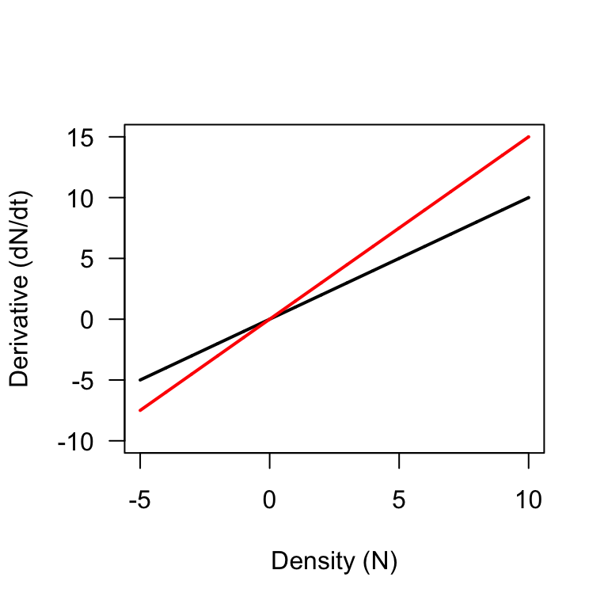

```r
densities <- seq(-5, 10, by = 0.01)
r_4.6a <- 1.0
r_4.6b <- 1.5
deriv_4.6a <- r_4.6a*densities
deriv_4.6b <- r_4.6b*densities
plot(x = densities, y = deriv_4.6a, ylim = c(-10, 15), type = "l", lwd = 2, xlab = "Density (N)", ylab = "Derivative (dN/dt)", las = 1)
lines(x = densities, y = deriv_4.6b, col = "red", lwd = 2)
```

### 4.7

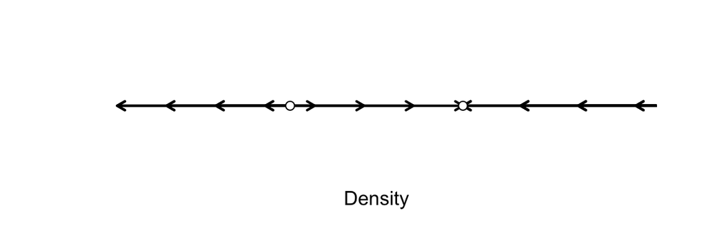

```r
K <- 1
arrow.heads.unstable <- seq(from = -1, to = 1, length.out = 8)
arrow.heads.stable <- seq(from = 1, to = 2, length.out = 4)
n.arrows <- length(c(arrow.heads.unstable, arrow.heads.stable))

plot(x = c(-1, 2), y = c(0, 0), type = "n", axes = F, xlab = "Density", ylab  = "")
arrows(x0 = rep(x = 0, times = n.arrows),
       x1 = arrow.heads.unstable,
       y0 = rep(x = 0, times = n.arrows),
       y1 = rep(x = 0, times = n.arrows), length = 0.075, lwd = 2)
arrows(x0 = rep(x = 2.25, times = n.arrows),
       x1 = arrow.heads.stable,
       y0 = rep(x = 0, times = n.arrows),
       y1 = rep(x = 0, times = n.arrows), length = 0.075, lwd = 2)

points(x = 0, y = 0, pch = 21, bg = "white")
text(x = 0, y = 0, labels = 0, pos = 1)
points(x = 1, y = 0, pch = 21, bg = "white")
text(x = 1, y = 0, labels = "K", pos = 1)
```

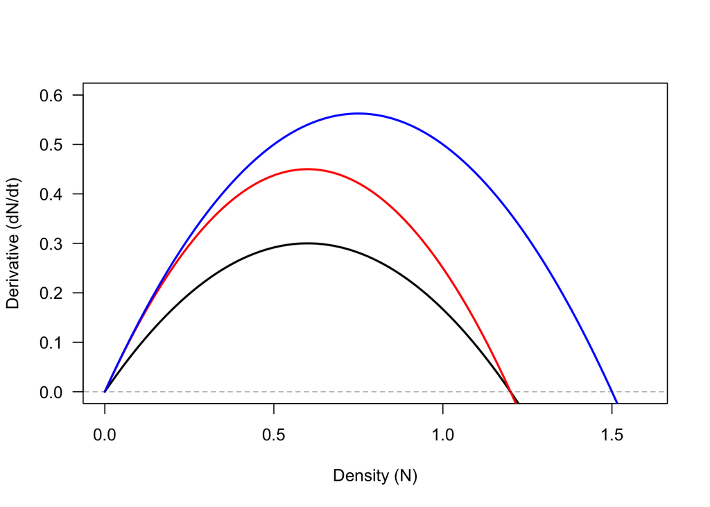

```r
densities_4.7 <- seq(0, 1.6, by = 0.01)
r_4.7a <- 1.0
r_4.7b <- 1.5
r_4.7c <- 1.5
K_4.7a <- 1.2
K_4.7b <- 1.2
K_4.7c <- 1.5
deriv_4.7a <- r_4.7a*densities_4.7*((K_4.7a - densities_4.7)/K_4.7a)
deriv_4.7b <- r_4.7b*densities_4.7*((K_4.7b - densities_4.7)/K_4.7b)
deriv_4.7c <- r_4.7c*densities_4.7*((K_4.7c - densities_4.7)/K_4.7c)
plot(x = densities_4.7, y = deriv_4.7a, ylim = c(0, 0.6), type = "l", lwd = 2, xlab = "Density (N)", ylab = "Derivative (dN/dt)", las = 1)
lines(x = densities_4.7, y = deriv_4.7b, lwd = 2, col = "red")
lines(x = densities_4.7, y = deriv_4.7c, lwd = 2, col = "blue")
segments(x0 = -1, x1 = 3, y0 = 0, y1 = 0, col = "#00000055", lty = "33")
```

### 4.8 (skip)

### 4.9

Assume that a population is growing according to the logistic equation. To make things simple, presume that the value of both $r$ and $K$ is 1.0 (i.e., we represent the population as varying between 0 and 1). The equilibrium value will be
$$0 = N - N^2$$
, which is a quadratic equation and has two roots, which are, by inspection, 0 and 1. Now suppose that a manager decides to impose a fixed harvesting rate on the popluation such that a constant number of individuals will be removed each year. A sensible model for this situation might be
$$\frac{dN}{dt} = N(1 - N) - N_F$$
, where $N_F$ is the fixed number (actually the proportion) of individuals removed. Plot the derivative versus $N$ for the following values of $N_F$: 0, 0.125, 0.25, and 0.5. Also, directly solve for the roots (using the quadrative formula; remember, $N_F$ is a constant). What do you conclude?

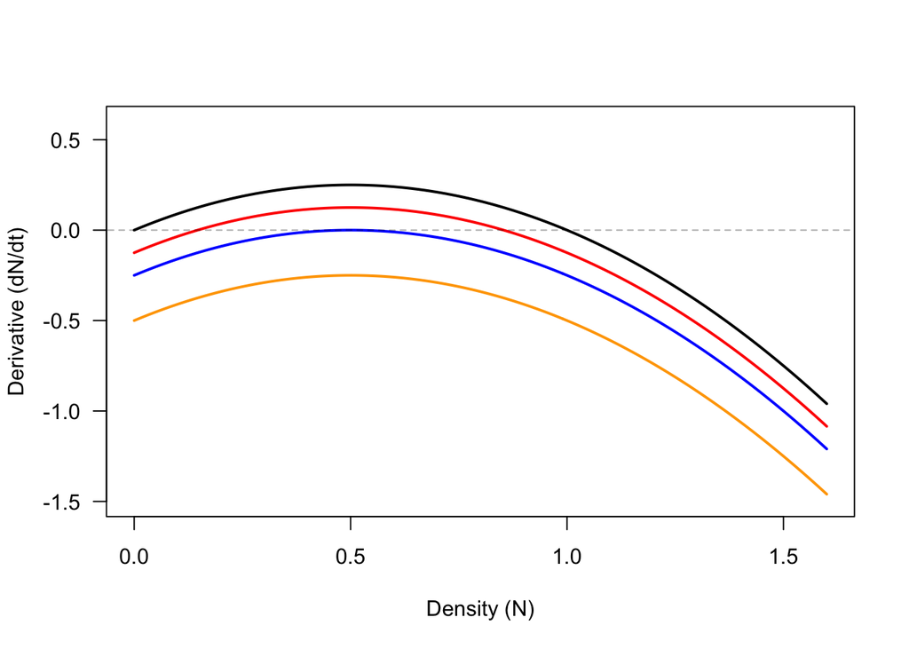

```r
densities_4.9 <- seq(0, 1.6, by = 0.01)

NFa <- 0
NFb <- 0.125
NFc <- 0.25
NFd <- 0.5

derv_4.9a <- densities_4.9*(1 - densities_4.9) - NFa
derv_4.9b <- densities_4.9*(1 - densities_4.9) - NFb
derv_4.9c <- densities_4.9*(1 - densities_4.9) - NFc
derv_4.9d <- densities_4.9*(1 - densities_4.9) - NFd
plot(x = densities_4.7, y = derv_4.9a, ylim = c(-1.5, 0.6), type = "l", lwd = 2, xlab = "Density (N)", ylab = "Derivative (dN/dt)", las = 1)
lines(x = densities_4.7, y = derv_4.9b, lwd = 2, col = "red")
lines(x = densities_4.7, y = derv_4.9c, lwd = 2, col = "blue")
lines(x = densities_4.7, y = derv_4.9d, lwd = 2, col = "orange")
segments(x0 = -1, x1 = 3, y0 = 0, y1 = 0, col = "#00000055", lty = "33")
```

### 4.10

In chapter 1 (exercise 1.17) you used the logistic map to project the population 50 times with values of $\lambda = 1.5\text{, }2.0\text{, }3.0\text{, and }3.5$. Do the same for $\lambda = 3.4\text{, } 3.5\text{, } 3.56\text{, } 3.565\text{, and } 3.567$, starting with 0.8 individuals and projecting 100 time steps. Note that at the end of the run the numbers tend to repeat themselves in a regular sequence. For example, for $\lambda = 3.4$ the numbers go from 0.452 to 0.842 and then back again to 0.452, which is to say that there is a two-point cycle. How many points are in the cycles at the ends of the runs of the other values of $\lambda$? Plot the number in a particular cycle versus the value of $\lambda$ that give those numbers.

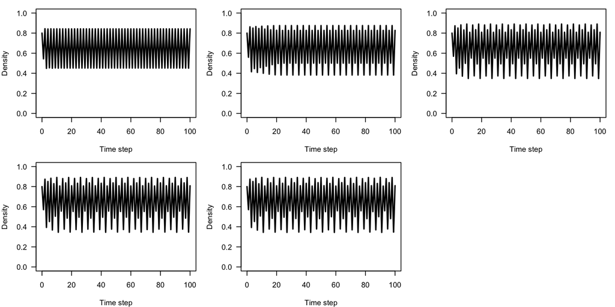

```r
La <- 3.4
Lb <- 3.5
Lc <- 3.56
Ld <- 3.565
Le <- 3.567
N0_4.10 <- 0.8
times_4.10 <- 0:100

log.map <- function(t, N, parms) {
  with(as.list(c(N, parms)), {
  Nt1 <- parms*N*(1 - N)
  return(list(Nt1))
})
}

out_4.10a <- ode(y = N0_4.10, func = log.map, times = times_4.10, parms = La, method = "iteration")
out_4.10b <- ode(y = N0_4.10, func = log.map, times = times_4.10, parms = Lb, method = "iteration")
out_4.10c <- ode(y = N0_4.10, func = log.map, times = times_4.10, parms = Lc, method = "iteration")
out_4.10d <- ode(y = N0_4.10, func = log.map, times = times_4.10, parms = Ld, method = "iteration")
out_4.10e <- ode(y = N0_4.10, func = log.map, times = times_4.10, parms = Le, method = "iteration")

par(mfrow = c(2, 3), mar = c(4, 4, 1, 1))
plot(x = out_4.10a[,1], y = out_4.10a[,2], las = 1, xlab = "Time step", ylab = "Density", lwd = 2, type = "l", ylim = c(0, 1))
plot(x = out_4.10b[,1], y = out_4.10b[,2], las = 1, xlab = "Time step", ylab = "Density", lwd = 2, type = "l", ylim = c(0, 1))
plot(x = out_4.10c[,1], y = out_4.10c[,2], las = 1, xlab = "Time step", ylab = "Density", lwd = 2, type = "l", ylim = c(0, 1))
plot(x = out_4.10d[,1], y = out_4.10d[,2], las = 1, xlab = "Time step", ylab = "Density", lwd = 2, type = "l", ylim = c(0, 1))
plot(x = out_4.10e[,1], y = out_4.10e[,2], las = 1, xlab = "Time step", ylab = "Density", lwd = 2, type = "l", ylim = c(0, 1))
```

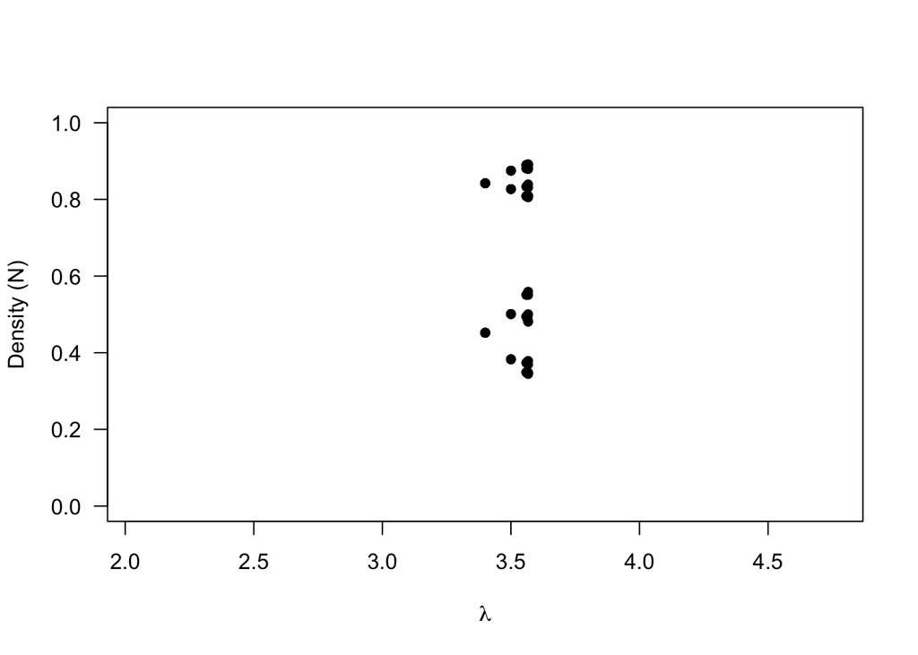

```r
plot(x = rep(x = 3.4, times = 20), y = out_4.10a[82:101,2], pch = 16, las = 1, xlab = bquote(lambda), ylab = "Density (N)", ylim = c(0, 1))
points(x = rep(x = 3.5, times = 20), y = out_4.10b[82:101,2], pch = 16)
points(x = rep(x = 3.56, times = 20), y = out_4.10c[82:101,2], pch = 16)
points(x = rep(x = 3.565, times = 20), y = out_4.10d[82:101,2], pch = 16)
points(x = rep(x = 3.567, times = 20), y = out_4.10e[82:101,2], pch = 16)
```

### 4.Extra

Now we wish to look to see how the cycling (or lack thereof) occurs over a greater range of $\lambda$. Create a sequence of $\lambda$s from 2.5 to 4 by one one-thousandth. Then, create a loop that numerically solves the logistic map for each value of $\lambda$ and ads points to a preexisting graph (change your pointsize using `cex = 0.25` [the default is 1.0] within `points()` and change your point types to solid using `pch = 16`). This will probably be your first bifurction diagram—revel in it after you’re finished.

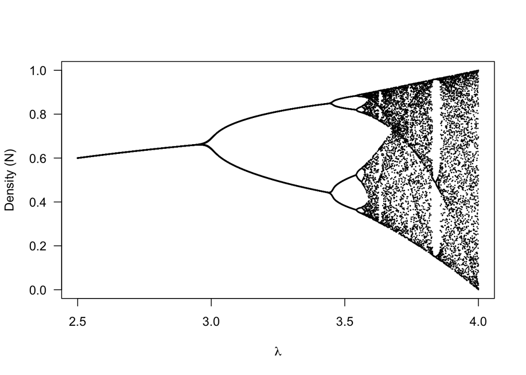

```r
lambdas <- seq(from = 2.5, to = 4, by = 0.001)
n.lambdas <- length(lambdas)
N0_4Ex <- 0.8
times_4Ex <- 0:100

log.map <- function(t, N, parms) {
  with(as.list(c(N, parms)), {
  Nt1 <- parms*N*(1 - N)
  return(list(Nt1))
})
}


plot(x = NA, type = "n", pch = 16, las = 1, xlab = bquote(lambda), ylab = "Density (N)", ylim = c(0, 1), xlim = c(2.5, 4))

for(i in 1:n.lambdas) {
out.loop <- ode(y = N0_4Ex, func = log.map, times = times_4Ex, parms = lambdas[i], method = "iteration")
points(x = rep(x = lambdas[i], times = 20), y = out.loop[82:101,2], pch = 16, cex = 0.25, col = "black")
}
```